# Regression Modelling to Predict the Age of the Abaolne based on its Physical Characteristics

Minoli Munasinghe

2023-04-10

Read the dataset from UCI machine learning repository

```r
# Read the dataset into a data frame
abalone_df <- read.csv("http://archive.ics.uci.edu/ml/machine-learning-databases/abalone/abalone.data", header=FALSE)
# Print first five rows in the data set
head(abalone_df)
```

```
##   V1    V2    V3    V4     V5     V6     V7    V8 V9
## 1  M 0.455 0.365 0.095 0.5140 0.2245 0.1010 0.150 15
## 2  M 0.350 0.265 0.090 0.2255 0.0995 0.0485 0.070  7
## 3  F 0.530 0.420 0.135 0.6770 0.2565 0.1415 0.210  9
## 4  M 0.440 0.365 0.125 0.5160 0.2155 0.1140 0.155 10
## 5  I 0.330 0.255 0.080 0.2050 0.0895 0.0395 0.055  7
## 6  I 0.425 0.300 0.095 0.3515 0.1410 0.0775 0.120  8
```

Add column names to the data set

```r
# add column names
names(abalone_df) <- c("sex", "length", "diameter", "height", "weight.whole",
                    "weight.shucked", "weight.viscera", "weight.shell", "rings")
```

Get the number of observations in the data

```r
# numbers of rows in the data set
nrow(abalone_df)
```

```
## [1] 4177
```

Get the number of columns in the data

```r
ncol(abalone_df)
```

```
## [1] 9
```

The data set has 4177 observations with 9 variables

Get the number of missing values

```r
# Check for the missing values
sum(is.na(abalone_df))
```

```
## [1] 0
```

The data set does not have any missing values

Get the structure of data

```r
str(abalone_df)
```

```
## 'data.frame':    4177 obs. of  9 variables:
##  $ sex           : chr  "M" "M" "F" "M" ...
##  $ length        : num  0.455 0.35 0.53 0.44 0.33 0.425 0.53 0.545 0.475 0.55 ...
##  $ diameter      : num  0.365 0.265 0.42 0.365 0.255 0.3 0.415 0.425 0.37 0.44 ...
##  $ height        : num  0.095 0.09 0.135 0.125 0.08 0.095 0.15 0.125 0.125 0.15 ...
##  $ weight.whole  : num  0.514 0.226 0.677 0.516 0.205 ...
##  $ weight.shucked: num  0.2245 0.0995 0.2565 0.2155 0.0895 ...
##  $ weight.viscera: num  0.101 0.0485 0.1415 0.114 0.0395 ...
##  $ weight.shell  : num  0.15 0.07 0.21 0.155 0.055 0.12 0.33 0.26 0.165 0.32 ...
##  $ rings         : int  15 7 9 10 7 8 20 16 9 19 ...
```

According to the data, there is one categorical variable (sex) and all the oher variables are continuous. The response variable of the model is rings.

The distribution of response variable

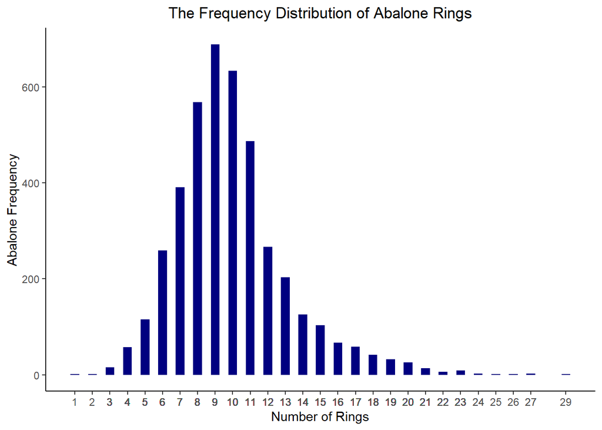

```r
library(ggplot2)
ggplot(aes(x = rings),data = abalone_df)+
geom_histogram(binwidth = 0.5,fill="navy blue") +
scale_x_continuous(breaks = abalone_df$rings)+
ylab("Abalone Frequency")+
xlab("Number of Rings")+
ggtitle("The Frequency Distribution of Abalone Rings")+
theme_classic() +
theme(plot.title = element_text(hjust = 0.5))
```

```r
find_outliers = function(x){
  q1 = quantile(x,probs = 0.25)
  q3 = quantile(x,probs = 0.75)

  IQR = q3 - q1

  status = x < q1 - (IQR*1.5) | x > q3 + (IQR*1.5)

}

remove_outliers=function(processed_data,cols = names(processed_data)) {

    for (col in cols) {
        processed_data = processed_data[!find_outliers(processed_data[[col]]), ]
    }
  return(processed_data)
}

abalone_df = remove_outliers(abalone_df,cols =
                                   c("length","diameter","height","weight.whole",
                                    "weight.shucked","weight.viscera","weight.shell"))
dim(abalone_df)
```

```
## [1] 4013    9
```

```r
# Convert sex to factor
sex_factor <- as.factor(abalone_df$sex)

# Convert factor levels to numeric values
abalone_df["sex"] = as.numeric(sex_factor)
```

Data Normalization

```r
abalone_df = scale(abalone_df,scale = TRUE,center = TRUE)
```

Split the dataset in to training and testing set

```r
set.seed(2023)

# Split data into training & testing
sample <- sample(c(TRUE, FALSE), nrow(abalone_df), replace=TRUE, prob=c(0.80,0.20))
train_set <- abalone_df[sample, ]
test_set <- abalone_df[!sample, ]

# Separate predictor and response data from training set
x_train <- train_set[,-9]
y_train <- train_set[,9]

# Separate predictor and response data from testing set
x_test <- test_set[,-9]
y_test <- test_set[,9]
```

```r
# ------Multiple Linear Regression model--------------------------------------------
library(car)
ml_model <- lm(rings~., data = as.data.frame(train_set))
summary(ml_model)
```

```
##
## Call:
## lm(formula = rings ~ ., data = as.data.frame(train_set))
##
## Residuals:
##     Min      1Q  Median      3Q     Max
## -2.8090 -0.4393 -0.1199  0.3014  4.3836
##
## Coefficients:
##                 Estimate Std. Error t value Pr(>|t|)
## (Intercept)     0.004966   0.012344   0.402    0.687
## sex             0.003404   0.012413   0.274    0.784
## length         -0.107598   0.076639  -1.404    0.160
## diameter        0.321748   0.077498   4.152 3.39e-05 ***
## height          0.276451   0.030896   8.948  < 2e-16 ***
## weight.whole    1.438109   0.123853  11.611  < 2e-16 ***
## weight.shucked -1.425679   0.063491 -22.455  < 2e-16 ***
## weight.viscera -0.373470   0.049669  -7.519 7.10e-14 ***
## weight.shell    0.390867   0.057792   6.763 1.59e-11 ***
## ---
## Signif. codes:  0 '***' 0.001 '**' 0.01 '*' 0.05 '.' 0.1 ' ' 1
##
## Residual standard error: 0.7025 on 3231 degrees of freedom
## Multiple R-squared:  0.5212, Adjusted R-squared:   0.52
## F-statistic: 439.6 on 8 and 3231 DF,  p-value: < 2.2e-16
```

```r
vif(ml_model)
```

```
##            sex         length       diameter         height   weight.whole
##       1.006056      38.848109      39.856606       6.319377     101.563956
## weight.shucked weight.viscera   weight.shell
##      26.528924      16.404005      22.249069
```

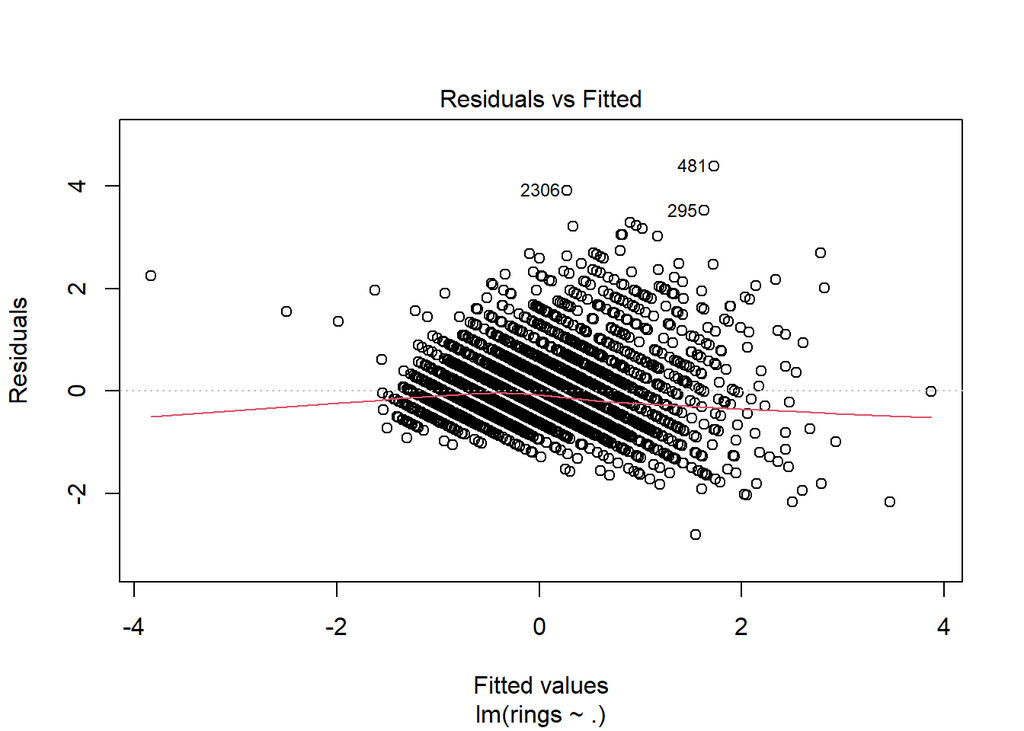

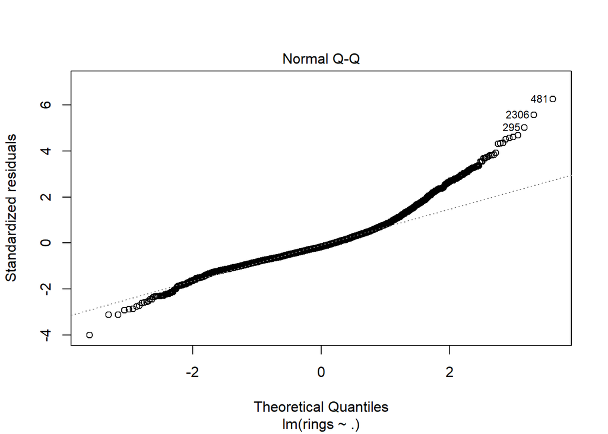

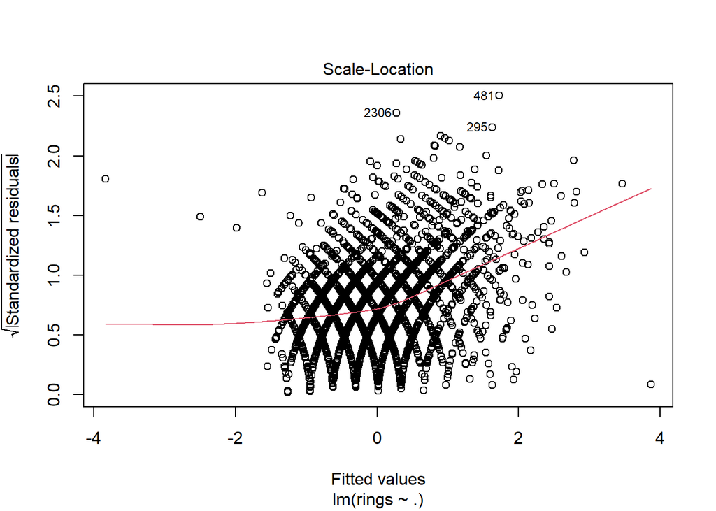

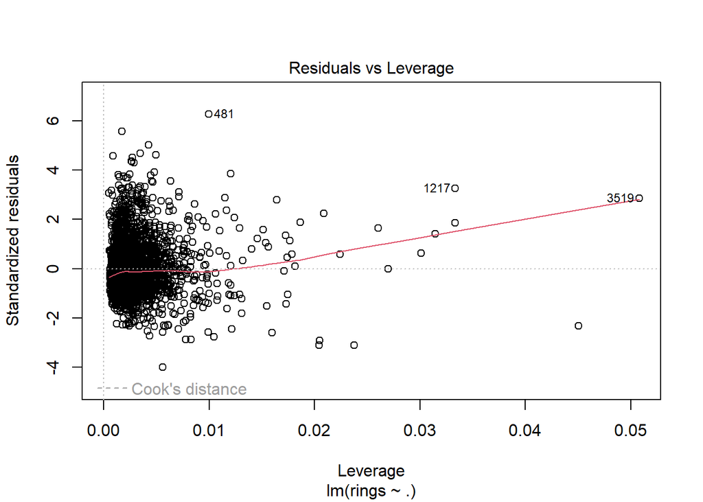

```r
plot(ml_model)
```

According to the plots, the multiple linear regression model assumptios are not satisfied.

Since the weight.whole variable have high VIF value, I will remove that from the predictor variables and fit the model again

```r
ml_model_2 <- lm(rings~.-weight.whole, data = as.data.frame(train_set))
summary(ml_model_2)
```

```
##
## Call:
## lm(formula = rings ~ . - weight.whole, data = as.data.frame(train_set))
##
## Residuals:
##     Min      1Q  Median      3Q     Max
## -2.7208 -0.4417 -0.1237  0.3060  5.0312
##
## Coefficients:
##                  Estimate Std. Error t value Pr(>|t|)
## (Intercept)     4.741e-03  1.260e-02   0.376    0.707
## sex             1.998e-05  1.266e-02   0.002    0.999
## length         -1.259e-01  7.819e-02  -1.610    0.108
## diameter        3.499e-01  7.905e-02   4.426 9.91e-06 ***
## height          2.897e-01  3.151e-02   9.193  < 2e-16 ***
## weight.shucked -8.259e-01  3.767e-02 -21.923  < 2e-16 ***
## weight.viscera -2.126e-02  4.014e-02  -0.530    0.596
## weight.shell    8.938e-01  3.905e-02  22.889  < 2e-16 ***
## ---
## Signif. codes:  0 '***' 0.001 '**' 0.01 '*' 0.05 '.' 0.1 ' ' 1
##
## Residual standard error: 0.7169 on 3232 degrees of freedom
## Multiple R-squared:  0.5012, Adjusted R-squared:  0.5001
## F-statistic: 463.9 on 7 and 3232 DF,  p-value: < 2.2e-16
```

However, removing the highly correlated predictors increase the RMSE and decrease the R squared values. Therefore, log transformation of the rings variable is used to predict the models